# InVivoStat Linear Regression Analysis

## Response and covariate

The Response1 response is currently being analysed by the Linear Regression Analysis module, with Covariate fitted as a covariate.The response has been loge transformed prior to analysis.

## Scatterplots of the observed data, including best-fit regression lines, on the transformed scale

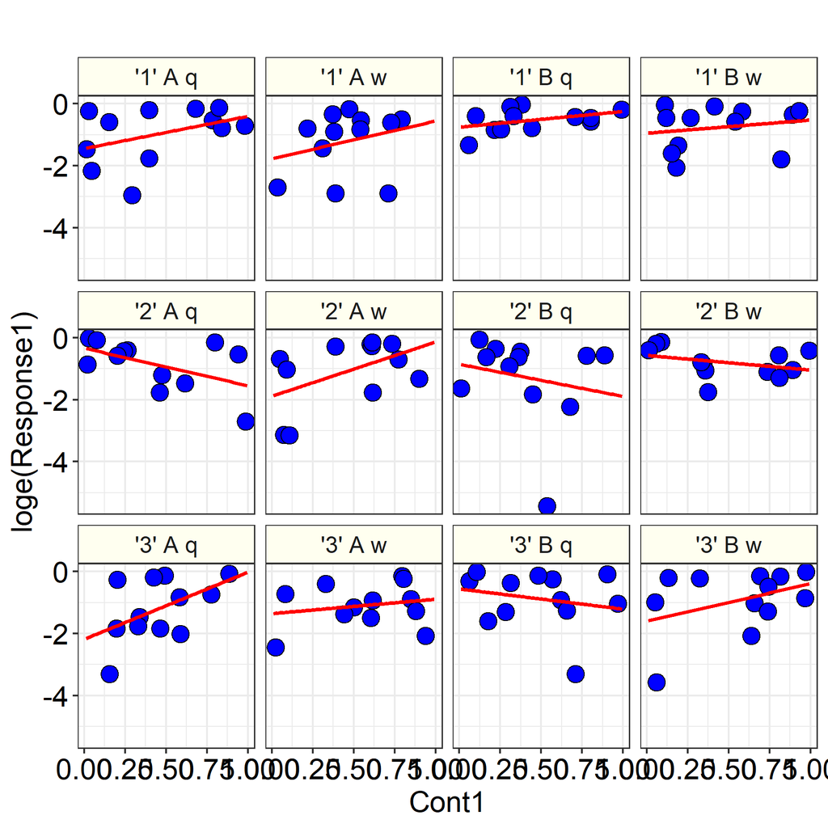

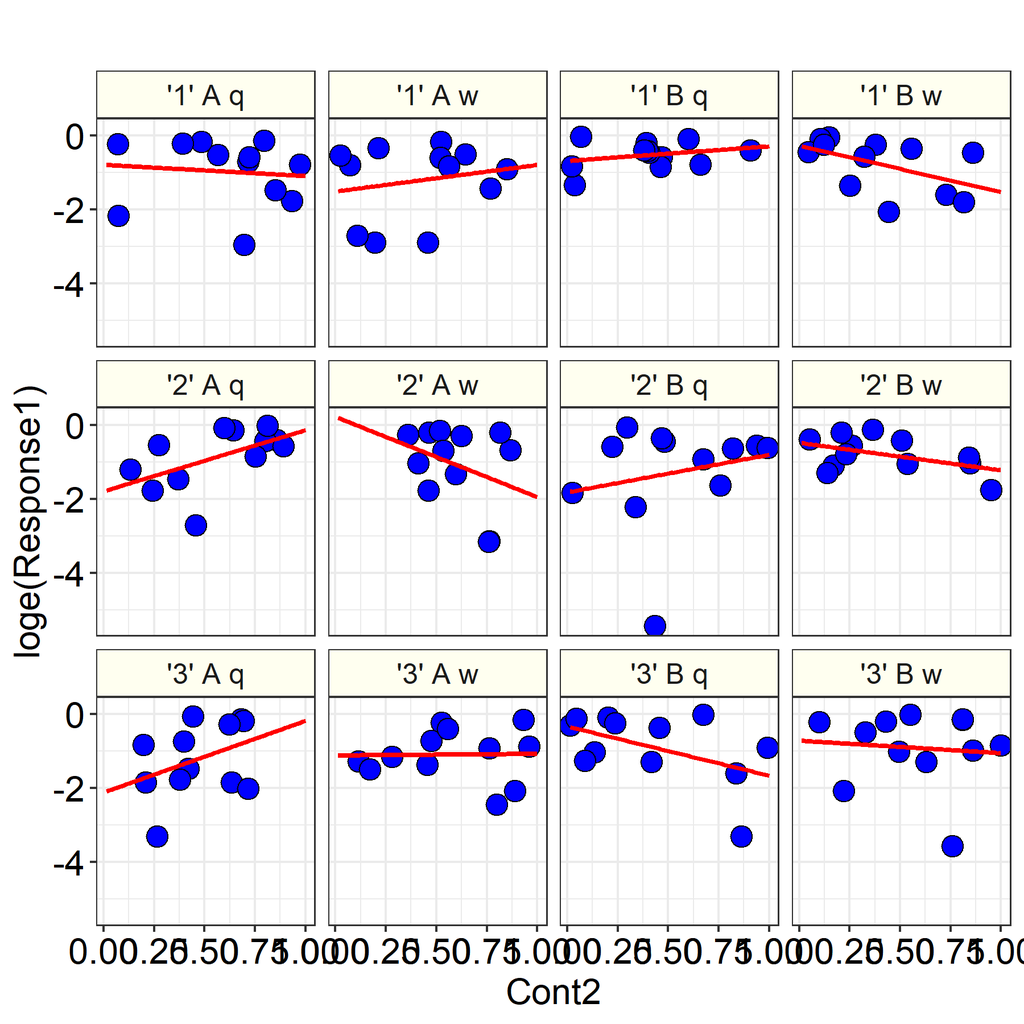

Note: The lines plotted here are not related to the fitted statistical model, but are individual best-fit regression lines.

Note: The best-fit regression lines included on the plot are not adjusted for the covariate or the blocking factor.

Note: As the number of continuous factors included in the analysis is more than one, the coefficients of the best-fit regression lines have not been calculated.

## Plot of the response vs. the covariate, categorised by the primary factor (on the transformed scale)

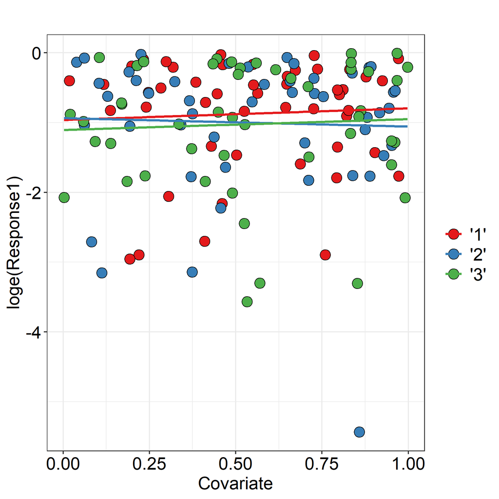

Tip: In order to decide whether it is helpful to fit the covariate, the following should be considered:

a) Is there a relationship between the response and the covariate? (N.B., It is only worth fitting the covariate if there is a strong positive (or negative) relationship between them: i.e., the lines on the plot should not be horizontal).

b) Is the relationship similar for all levels of the categorical factor? (The lines on the plot should be approximately parallel).

c) Is the covariate influenced by the categorisation factor? (We assume the covariate is not influenced by the categorisation factor and so there should be no separation of the categorisation factor levels along the x-axis on the plot).

These issues are discussed in more detail in Morris (1999).

## Analysis of Covariance (ANCOVA) table for assessing covariate interactions

| Effect | Sums of squares | Degrees of freedom | Mean square | F-value | p-value |
| --- | --- | --- | --- | --- | --- |
| Covariate | 1.09 | 1 | 1.089 | 1.29 | 0.2588 |
| Cont1 | 0.34 | 1 | 0.338 | 0.40 | 0.5285 |
| Cont2 | 0.72 | 1 | 0.716 | 0.85 | 0.3593 |
| Cat1 | 2.08 | 2 | 1.042 | 1.24 | 0.2954 |
| Cat&2 | 1.99 | 1 | 1.987 | 2.36 | 0.1283 |
| Cat$3 | 0.92 | 1 | 0.919 | 1.09 | 0.2993 |
| Block1 | 4.21 | 2 | 2.105 | 2.50 | 0.0882 |
| Cont1 * Cont2 | 0.39 | 1 | 0.385 | 0.46 | 0.5010 |
| Cont1 * Cat1 | 3.61 | 2 | 1.803 | 2.14 | 0.1240 |
| Cont2 * Cat1 | 1.05 | 2 | 0.526 | 0.62 | 0.5385 |
| Cont1 * Cat&2 | 0.63 | 1 | 0.633 | 0.75 | 0.3887 |
| Cont2 * Cat&2 | 0.55 | 1 | 0.552 | 0.65 | 0.4206 |
| Cat1 * Cat&2 | 1.25 | 2 | 0.626 | 0.74 | 0.4789 |
| Cont1 * Cat$3 | 1.36 | 1 | 1.360 | 1.61 | 0.2075 |
| Cont2 * Cat$3 | 3.33 | 1 | 3.332 | 3.95 | 0.0499 |
| Cat1 * Cat$3 | 2.36 | 2 | 1.182 | 1.40 | 0.2517 |
| Cat&2 * Cat$3 | 1.38 | 1 | 1.381 | 1.64 | 0.2040 |
| Covariate * Cont1 | 0.01 | 1 | 0.007 | 0.01 | 0.9300 |
| Covariate * Cont2 | 1.16 | 1 | 1.162 | 1.38 | 0.2435 |
| Covariate * Cat1 | 0.59 | 2 | 0.297 | 0.35 | 0.7041 |
| Covariate * Cat&2 | 0.59 | 1 | 0.587 | 0.70 | 0.4064 |
| Covariate * Cat$3 | 0.16 | 1 | 0.160 | 0.19 | 0.6643 |
| Cont1 * Cont2 * Cat1 | 2.48 | 2 | 1.241 | 1.47 | 0.2351 |
| Cont1 * Cont2 * Cat&2 | 0.15 | 1 | 0.152 | 0.18 | 0.6720 |
| Cont1 * Cat1 * Cat&2 | 1.18 | 2 | 0.589 | 0.70 | 0.4999 |
| Cont2 * Cat1 * Cat&2 | 1.64 | 2 | 0.818 | 0.97 | 0.3831 |
| Cont1 * Cont2 * Cat$3 | 2.49 | 1 | 2.487 | 2.95 | 0.0895 |
| Cont1 * Cat1 * Cat$3 | 1.56 | 2 | 0.779 | 0.92 | 0.4007 |
| Cont2 * Cat1 * Cat$3 | 2.31 | 2 | 1.153 | 1.37 | 0.2600 |
| Cont1 * Cat&2 * Cat$3 | 1.61 | 1 | 1.608 | 1.91 | 0.1708 |
| Cont2 * Cat&2 * Cat$3 | 1.00 | 1 | 1.003 | 1.19 | 0.2783 |
| Cat1 * Cat&2 * Cat$3 | 2.34 | 2 | 1.170 | 1.39 | 0.2551 |
| Cont1 * Cont2 * Cat1 * Cat&2 | 1.36 | 2 | 0.681 | 0.81 | 0.4494 |
| Cont1 * Cont2 * Cat1 * Cat$3 | 2.01 | 2 | 1.005 | 1.19 | 0.3085 |
| Cont1 * Cont2 * Cat&2 * Cat$3 | 0.83 | 1 | 0.831 | 0.99 | 0.3234 |
| Cont1 * Cat1 * Cat&2 * Cat$3 | 1.02 | 2 | 0.509 | 0.60 | 0.5491 |
| Cont2 * Cat1 * Cat&2 * Cat$3 | 2.06 | 2 | 1.028 | 1.22 | 0.3005 |
| Cont1 * Cont2 * Cat1 * Cat&2 * Cat$3 | 0.86 | 2 | 0.430 | 0.51 | 0.6025 |
| Residual | 73.34 | 87 | 0.843 |  |  |

Note: This table should only be used to assess the covariate interactions. The statistical model used to generate all the remaining results in this output does not include the covariate interactions.

## Analysis of Covariance (ANCOVA) table

| Effect | Sums of squares | Degrees of freedom | Mean square | F-value | p-value |
| --- | --- | --- | --- | --- | --- |
| Covariate | 0.26 | 1 | 0.260 | 0.32 | 0.5732 |
| Cont1 | 0.63 | 1 | 0.632 | 0.78 | 0.3805 |
| Cont2 | 0.06 | 1 | 0.063 | 0.08 | 0.7809 |
| Cat1 | 1.09 | 2 | 0.543 | 0.67 | 0.5159 |
| Cat&2 | 1.37 | 1 | 1.369 | 1.68 | 0.1980 |
| Cat$3 | 2.00 | 1 | 2.000 | 2.46 | 0.1204 |
| Block1 | 4.55 | 2 | 2.274 | 2.79 | 0.0663 |
| Cont1 * Cont2 | 0.66 | 1 | 0.658 | 0.81 | 0.3708 |
| Cont1 * Cat1 | 3.55 | 2 | 1.774 | 2.18 | 0.1188 |
| Cont2 * Cat1 | 0.86 | 2 | 0.432 | 0.53 | 0.5903 |
| Cont1 * Cat&2 | 0.75 | 1 | 0.754 | 0.93 | 0.3383 |
| Cont2 * Cat&2 | 0.69 | 1 | 0.693 | 0.85 | 0.3585 |
| Cat1 * Cat&2 | 1.13 | 2 | 0.567 | 0.70 | 0.5007 |
| Cont1 * Cat$3 | 1.58 | 1 | 1.579 | 1.94 | 0.1670 |
| Cont2 * Cat$3 | 4.10 | 1 | 4.099 | 5.04 | 0.0272 |
| Cat1 * Cat$3 | 2.72 | 2 | 1.358 | 1.67 | 0.1942 |
| Cat&2 * Cat$3 | 1.36 | 1 | 1.359 | 1.67 | 0.1996 |
| Cont1 * Cont2 * Cat1 | 2.63 | 2 | 1.313 | 1.61 | 0.2047 |
| Cont1 * Cont2 * Cat&2 | 0.25 | 1 | 0.252 | 0.31 | 0.5793 |
| Cont1 * Cat1 * Cat&2 | 0.99 | 2 | 0.496 | 0.61 | 0.5461 |
| Cont2 * Cat1 * Cat&2 | 1.49 | 2 | 0.746 | 0.92 | 0.4035 |
| Cont1 * Cont2 * Cat$3 | 2.86 | 1 | 2.858 | 3.51 | 0.0641 |
| Cont1 * Cat1 * Cat$3 | 1.92 | 2 | 0.958 | 1.18 | 0.3128 |
| Cont2 * Cat1 * Cat$3 | 2.54 | 2 | 1.270 | 1.56 | 0.2157 |
| Cont1 * Cat&2 * Cat$3 | 1.56 | 1 | 1.562 | 1.92 | 0.1693 |
| Cont2 * Cat&2 * Cat$3 | 0.89 | 1 | 0.885 | 1.09 | 0.2998 |
| Cat1 * Cat&2 * Cat$3 | 3.45 | 2 | 1.726 | 2.12 | 0.1257 |
| Cont1 * Cont2 * Cat1 * Cat&2 | 1.12 | 2 | 0.560 | 0.69 | 0.5052 |
| Cont1 * Cont2 * Cat1 * Cat$3 | 2.25 | 2 | 1.123 | 1.38 | 0.2567 |
| Cont1 * Cont2 * Cat&2 * Cat$3 | 0.66 | 1 | 0.658 | 0.81 | 0.3710 |
| Cont1 * Cat1 * Cat&2 * Cat$3 | 1.54 | 2 | 0.772 | 0.95 | 0.3909 |
| Cont2 * Cat1 * Cat&2 * Cat$3 | 3.46 | 2 | 1.728 | 2.12 | 0.1254 |
| Cont1 * Cont2 * Cat1 * Cat&2 * Cat$3 | 1.38 | 2 | 0.690 | 0.85 | 0.4316 |
| Residual | 75.70 | 93 | 0.814 |  |  |

Comment: ANCOVA table calculated using a Type III model fit, see Armitage et al. (2001).

Conclusion: There is a statistically significant overall effect of Cont2 * Cat$3.

## Table of model coefficients

|  | Estimate | Lower 95% CI | Upper 95% CI |
| --- | --- | --- | --- |
| (Intercept) | -0.2899 | -3.2977 | 2.7180 |
| Covariate | 0.1784 | -0.4482 | 0.8049 |
| Cont1 | -0.9761 | -6.1569 | 4.2047 |
| Cont2 | -2.3168 | -6.6121 | 1.9784 |
| Cat1'1' | -0.8949 | -4.2668 | 2.4770 |
| Cat1'2' | -0.0948 | -3.4252 | 3.2355 |
| Cat&2A | 0.5926 | -4.4260 | 5.6112 |
| Cat$3q | -0.0397 | -3.4848 | 3.4054 |
| Block1'1' | 0.3684 | -0.0235 | 0.7604 |
| Block1'2' | -0.0837 | -0.4920 | 0.3245 |
| Cont1 * Cont2 | 3.1834 | -3.9355 | 10.3023 |
| Cont1 * Cat1'1' | 2.7927 | -3.6708 | 9.2563 |
| Cont1 * Cat1'2' | -0.0401 | -5.9299 | 5.8496 |
| Cont2 * Cat1'1' | 1.7703 | -3.6771 | 7.2177 |
| Cont2 * Cat1'2' | 1.1315 | -4.4419 | 6.7049 |
| Cont1 * Cat&2A | -1.0333 | -8.7764 | 6.7099 |
| Cont2 * Cat&2A | -0.7542 | -8.4465 | 6.9380 |
| Cat1'1' * Cat&2A | -1.6900 | -7.2979 | 3.9179 |
| Cat1'2' * Cat&2A | -0.0629 | -6.7179 | 6.5921 |
| Cont1 * Cat$3q | 0.7436 | -5.1185 | 6.6058 |
| Cont2 * Cat$3q | 1.9367 | -3.5137 | 7.3870 |
| Cat1'1' * Cat$3q | -0.4022 | -4.7168 | 3.9125 |
| Cat1'2' * Cat$3q | -0.0960 | -4.7731 | 4.5812 |
| Cat&2A * Cat$3q | -6.1677 | -12.4966 | 0.1611 |
| Cont1 * Cont2 * Cat1'1' | -5.1077 | -15.4245 | 5.2091 |
| Cont1 * Cont2 * Cat1'2' | -1.4084 | -11.0473 | 8.2305 |
| Cont1 * Cont2 * Cat&2A | 0.7442 | -10.3911 | 11.8794 |
| Cont1 * Cat1'1' * Cat&2A | 1.2945 | -8.8594 | 11.4484 |
| Cont1 * Cat1'2' * Cat&2A | -0.3999 | -11.8713 | 11.0714 |
| Cont2 * Cat1'1' * Cat&2A | 2.5829 | -7.1633 | 12.3291 |
| Cont2 * Cat1'2' * Cat&2A | -0.9027 | -11.1357 | 9.3302 |
| Cont1 * Cont2 * Cat$3q | -5.7879 | -15.0059 | 3.4301 |
| Cont1 * Cat1'1' * Cat$3q | 0.5461 | -9.6743 | 10.7665 |
| Cont1 * Cat1'2' * Cat$3q | -2.8346 | -11.1458 | 5.4765 |
| Cont2 * Cat1'1' * Cat$3q | 0.8797 | -7.9313 | 9.6908 |
| Cont2 * Cat1'2' * Cat$3q | -1.4497 | -9.2073 | 6.3078 |
| Cont1 * Cat&2A * Cat$3q | 10.3644 | -0.9994 | 21.7283 |
| Cont2 * Cat&2A * Cat$3q | 10.2907 | -1.5200 | 22.1014 |
| Cat1'1' * Cat&2A * Cat$3q | 7.4635 | 0.2102 | 14.7168 |
| Cat1'2' * Cat&2A * Cat$3q | 4.6160 | -4.3905 | 13.6225 |
| Cont1 * Cont2 * Cat1'1' * Cat&2A | -1.7828 | -19.6607 | 16.0952 |
| Cont1 * Cont2 * Cat1'2' * Cat&2A | 2.9462 | -14.7171 | 20.6095 |
| Cont1 * Cont2 * Cat1'1' * Cat$3q | 0.6608 | -22.1699 | 23.4916 |
| Cont1 * Cont2 * Cat1'2' * Cat$3q | 7.2283 | -6.4009 | 20.8576 |
| Cont1 * Cont2 * Cat&2A * Cat$3q | -15.9376 | -38.3888 | 6.5136 |
| Cont1 * Cat1'1' * Cat&2A * Cat$3q | -10.9608 | -26.7826 | 4.8610 |
| Cont1 * Cat1'2' * Cat&2A * Cat$3q | -6.0699 | -22.5828 | 10.4430 |
| Cont2 * Cat1'1' * Cat&2A * Cat$3q | -14.9778 | -29.7681 | -0.1875 |
| Cont2 * Cat1'2' * Cat&2A * Cat$3q | -6.5452 | -21.6970 | 8.6065 |
| Cont1 * Cont2 * Cat1'1' * Cat&2A * Cat$3q | 22.0317 | -11.6699 | 55.7334 |
| Cont1 * Cont2 * Cat1'2' * Cat&2A * Cat$3q | 8.1331 | -21.5443 | 37.8105 |

Note: These model coefficients can be added together to obtain the model-based estimates of the relationships between the factors and the response, see Chambers and Hastie (1992).

## Covariate regression coefficient

| Covariate | Estimate | Std error | t-value | p-value |
| --- | --- | --- | --- | --- |
| Covariate | 0.178 | 0.316 | 0.57 | 0.5732 |

## R-squared and Adjusted R-squared statistics

|  | R-squared | Adjusted R-sq |
| --- | --- | --- |
| Estimate | 0.3605 | 0.0167 |

The R-squared is the fraction of the variance explained by the model. A value close to 1 implies the statistical model fits the data well. Unfortunately adding additional variables to the statistical model will always increase R-sq, regardless of their importance. The Adjusted R-sq adjusts for the number of terms in the model and may decrease if over-fitting has occurred. If there is a large difference between R-sq and Adjusted R-sq, then non-significant terms may have been included in the statistical model.

## Diagnostic plots

### Residuals vs. predicted plot

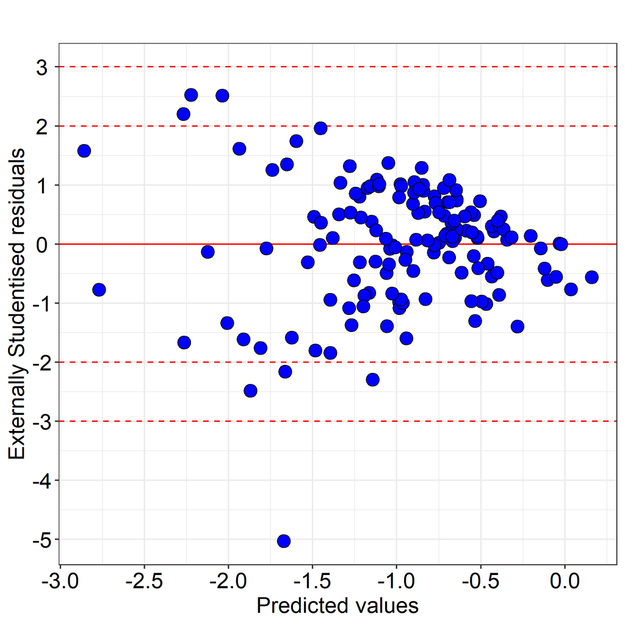

Tip: On this plot look to see if the spread of the points increases as the predicted values increase. If so the response may need transforming.

Tip: Any observation with a residual less than -3 or greater than 3 (SD) should be investigated as a possible outlier.

### Normal probability plot

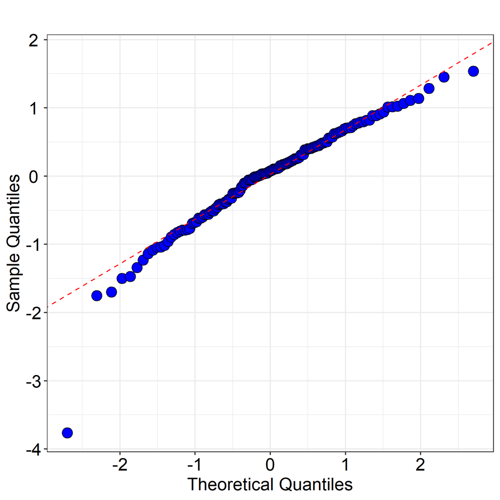

Tip: Check that the points lie along the dotted line. If not then the data may be non-normally distributed.

## Cook's distance plot

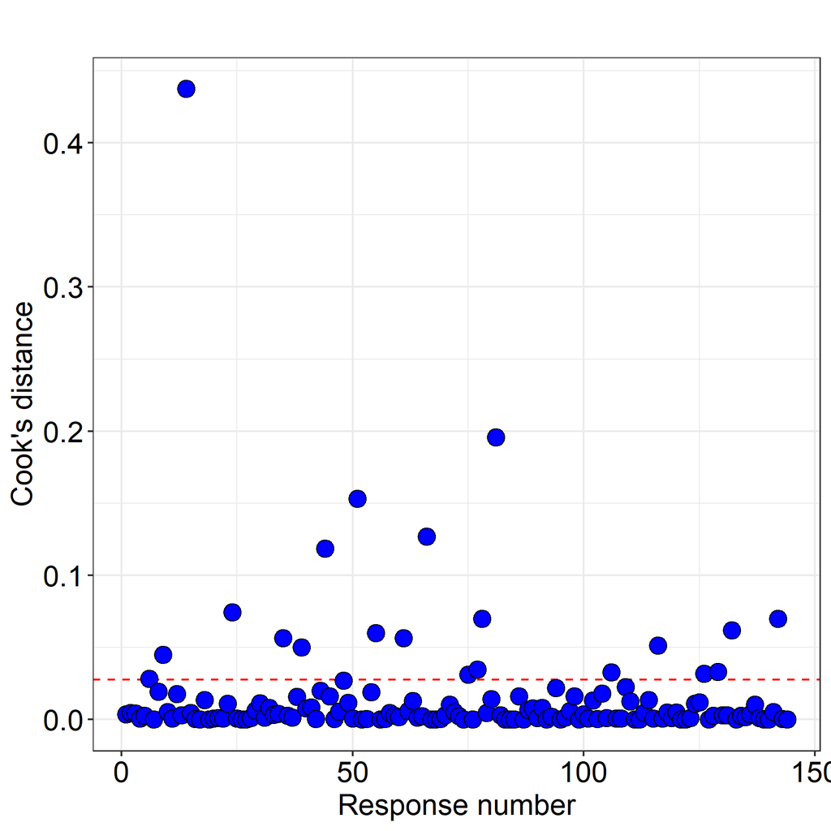

This plot should be used to assess whether there are any potential outliers in the dataset. Observations where the Cook's distance are above the cut-off line should be investigated further. Note the cut-off line has been calculated using the 4/n approach, where n is the number of observations in the dataset.

## Leverage plot

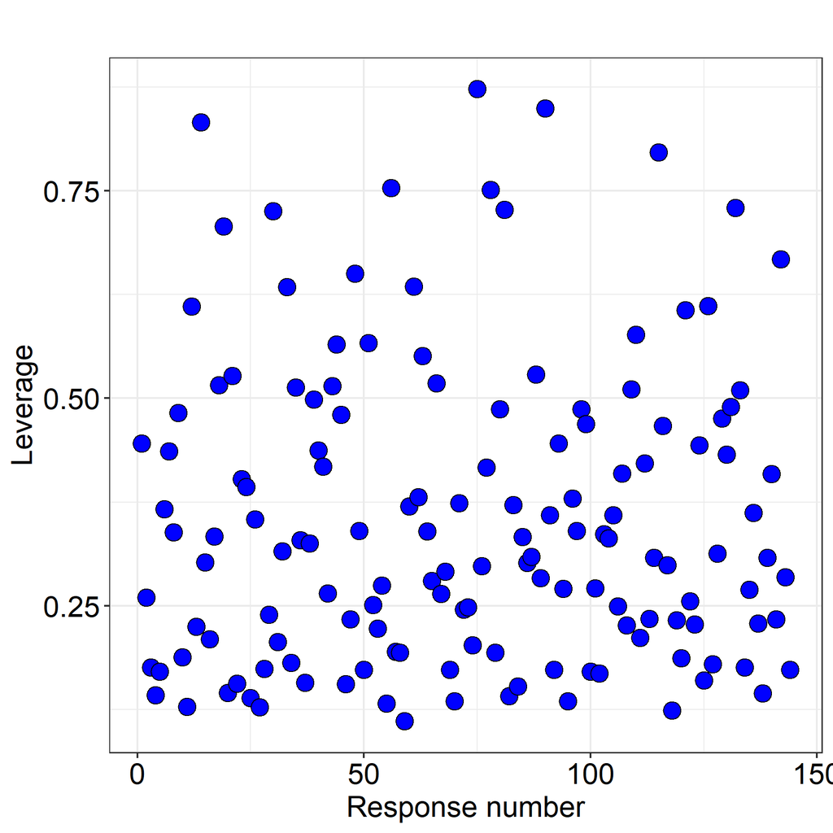

This plot indicates the relative influence of the observations. Observations with a high leverage may be unduly influencing the statistical model.

## Analysis description

The data were analysed using an 5-way ANCOVA approach, with Cont1 and Cont2 as the continuous factors, Cat1, Cat&2 and Cat$3 as the categorical factors, Block1 as a blocking factor and Covariate as the covariate. The response was loge transformed prior to analysis to stabilise the variance.

For more information on the theoretical approaches that are implemented within this module, see Bate and Clark (2014).

## References

When referring to InVivoStat, please cite 'InVivoStat, version 5.2.0'.

Bate, S.T. and Clark, R.A. (2014). The Design and Statistical Analysis of Animal Experiments. Cambridge University Press.

Armitage, P., Matthews, J.N.S. and Berry, G. (2001). Statistical Methods in Medical Research. 4th edition; John Wiley & Sons. New York.

Chambers, J.M. and Hastie, T.J. (1992). Statistical Models in S. Wadsworth and Brooks-Cole advanced books and software.

Morris, T.R. (1999). Experimental Design and Analysis in Animal Sciences. CABI publishing. Wallingford, Oxon (UK).